# Salidas laborales

El País ha publicado una serie de datos sobre empleo y titulación universitaria. Por su interés merece la pena reproducir los resultados relacionados con criminología aquí.

Los datos reflejan el porcentaje de titulados dados de alta en la seguridad social y su titulación de origen. Estos datos no nos permiten valorar si los graduados están trabajando en un área relacionada con la de sus estudios, pero a pesar de ellos son interesantes. En la nota de prensa de El País se reflejan los datos de solamente 9 de las titulaciones de criminologia y una de las características mas sobresalientes es que destacan un alto grado de variabilidad en la fortuna de los estudiantes en función de donde estudiaron criminologia.

```
##                  Universidad N..Titulados X2014.
## 1          Central Barcelona          115   84.3
## 2                     Girona           28   78.6
## 3         Autonoma Barcelona           41   70.7
## 4 Internacional de Catalunya           34   61.8
## 5                   Alicante          119   58.8
## 6                     Murcia          146   56.2
## 7                   Valencia          174   55.7
## 8           Camilo Jose Cela           46   45.7
## 9          Europea de Madrid           11   45.5
```

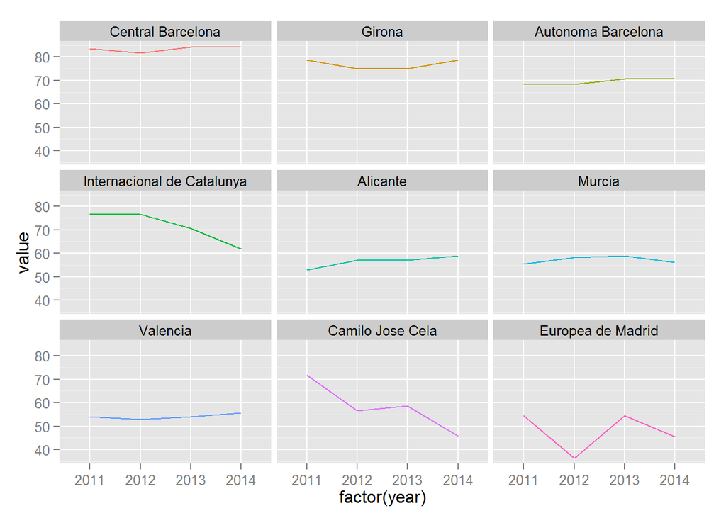

Las cuatro universidades catalanas, que fueron de las primeras en sacar estos títulos, son las que presentan mejores resultados. Particularmente notables son los resultados de la Central de Barcelona, sobre todo, como veremos luego cuando los comparamos con la totalidad de titulaciones universitarias.

Es importante, no obstante, considerar que estos datos así tabulados no toman en consideración una serie de factores que seguramente también cuentan a la hora de interpretar las diferencias. En un contexto con tan poca movilidad estudiantil como el de España, es muy posible que estas diferencias también reflejen las condiciones locales del mercado laboral en la ciudad en cuestión. Tampoco nos permiten estimar el valor añadido de ir a una universidad frente a otra, ya que aquí nos estamos controlando características del cuerpo estudiantil (p.ej.., es muy probable que, en cierto grado, estudiantes con distintas habilidades y capital social vayan a distintas universidades/titulaciones).

Este ultimo gráfico, un tanto guarrote (pero no tengo tiempo para mas), os da una idea de donde se sitúa cada titulación de criminologia para la que tenemos datos en relación con las demás titulaciones españolas.

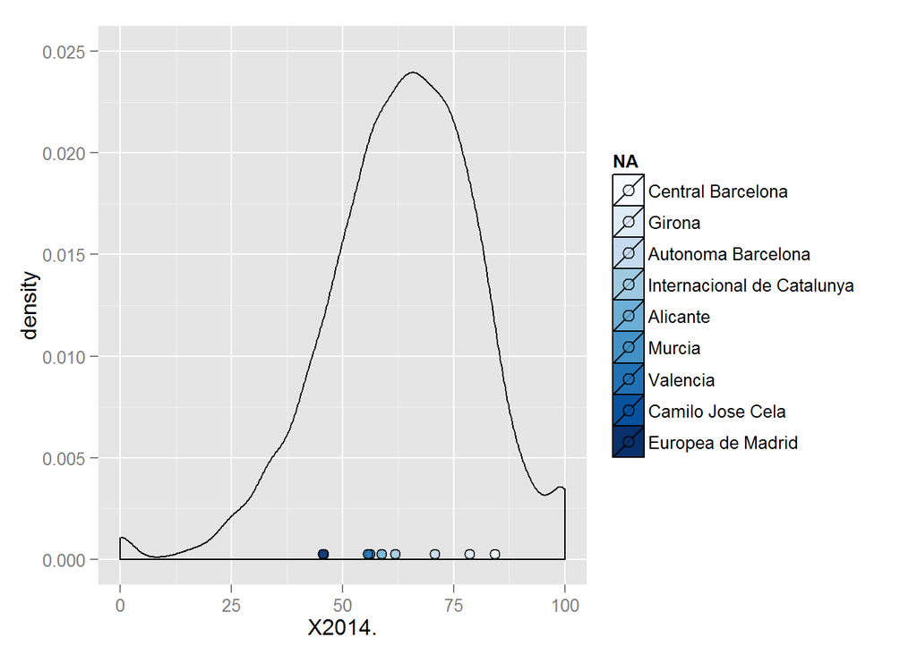

Es aquí donde se percibe mas claramente que la Central de Barcelona, Girona y la Autonoma de Barcelona son las que estan asociadas mejores resultados (con esta medida un tanto imperfecta) para sus alumnos. Pero de nuevo insisto, hay que tomar en consideracion otros factores antes de hacer lecturas de tipo casual. Correlation is not causation.

```
##                  Universidad percentile
## 1          Central Barcelona     0.9133
## 2                     Girona     0.8244
## 3         Autonoma Barcelona     0.6495
## 4 Internacional de Catalunya     0.4387
## 5                   Alicante     0.3741
## 6                     Murcia     0.3120
## 7                   Valencia     0.3023
## 8           Camilo Jose Cela     0.1413
## 9          Europea de Madrid     0.1398
```